# Distribuciones univariante

Autores/as

Mario Camacho

Raúl Castañeda

Fecha de publicación

20 octubre 2025

**Stakeholder:** Jose L Merino Rivas **Centro:** Hospital del Henares  
**Fecha última modificación:** 23 marzo 2026

```r
aux <- readRDS("data/data.RDA")
data <- aux$data
```

## Control n meses

En cada control se excluyen los casos con éxitus registrado para ese mes.

**Variables basales.**

```r
data |> select(-contains("Control")) |> summary()
```

```
       id        HD       Aleatorización Sexo   Fecha nacimiento
 Min.   : 1.00   0:59   Venofer  :30     0:44   Min.   :1934-10-24
 1st Qu.:16.75   1: 5   Ferinject:34     1:20   1st Qu.:1946-08-30
 Median :32.50                                  Median :1952-08-19
 Mean   :32.50                                  Mean   :1956-04-23
 3rd Qu.:48.25                                  3rd Qu.:1967-01-24
 Max.   :64.00                                  Max.   :1989-03-17

      Edad       DM     Sintrom                   Etiologia - ERC
 Min.   :32.00   0:30   0   :47   Nefropatía diabética    :15
 1st Qu.:53.75   1:34   1   :16   ERC no filiada          : 3
 Median :65.00          NA's: 1   GN membranoproliferativa: 2
 Mean   :62.66                    GN mesangial            : 2
 3rd Qu.:74.25                    Nefroangioesclerosis    : 2
 Max.   :86.00                    Nefropatía diabétca     : 2
                                  (Other)                 :38
 Etiologia - ERC (código) Fecha inicio HD      Fecha inicio Estudio
 0: 5                     Min.   :2007-08-24   Min.   :2023-06-01
 1:23                     1st Qu.:2017-02-04   1st Qu.:2023-06-01
 2:18                     Median :2020-08-02   Median :2023-06-01
 3: 5                     Mean   :2019-06-18   Mean   :2023-06-01
 4: 5                     3rd Qu.:2021-11-29   3rd Qu.:2023-06-01
 5: 3                     Max.   :2023-04-18   Max.   :2023-06-01
 6: 5
 Tiempo hasta inicio estudio (meses) FAV RC FAV HC FAV HB   Es exitus
 Min.   :  1.00                      0:53   0:47   0:63   Min.   :1
 1st Qu.: 17.75                      1:11   1:17   1: 1   1st Qu.:1
 Median : 33.50                                           Median :1
 Mean   : 46.98                                           Mean   :1
 3rd Qu.: 75.25                                           3rd Qu.:1
 Max.   :189.00                                           Max.   :1
                                                          NA's   :58
                       Momento exitus
 Control 10 meses Causa exitus: 1
 Control 2 meses Causa exitus : 1
 Control 4 meses Causa exitus : 2
 Control 6 meses Causa exitus : 1
 Control 8 meses Causa exitus : 1
 NA's                         :58
```

**Control 0 meses.**

```
   Es exitus                        Momento exitus
 Min.   :1    Control 10 meses Causa exitus: 1
 1st Qu.:1    Control 2 meses Causa exitus : 1
 Median :1    Control 4 meses Causa exitus : 2
 Mean   :1    Control 6 meses Causa exitus : 1
 3rd Qu.:1    Control 8 meses Causa exitus : 1
 Max.   :1    NA's                         :58
 NA's   :58
```

**Control 2 meses.**

```
                                       n n_missing    mean      sd   min
Es exitus                              5        58    1.00    0.00   1.0
Hb                                    60         3   12.21    1.42   9.3
Hto                                   60         3   37.77    4.74  28.4
PL                                    60         3  174.38   55.81  61.0
Ferritina                             59         4  386.22  203.91  41.0
IST                                   59         4   27.70    9.78  11.8
Na                                    60         3  138.18    3.41 129.0
K                                     60         3    5.14    0.73   3.5
Ca                                    60         3    8.51    0.72   5.8
P                                     60         3    4.72    1.47   2.0
Alb                                   60         3    3.28    0.44   2.1
Dosis FEE semanal Beta eritropoyetina 42        21 6666.67 7962.31   0.0
Dosis FEE semanal Darbepoetina        20        43   31.00   22.86   5.0
Cambio FEE                            62         1    0.56    0.50   0.0
Suspendido FEE                        62         1    0.18    0.39   0.0
Dosis Fe semanal                      62         1   62.10   79.86   0.0
Cambio Fe                             62         1    0.79    0.41   0.0
Suspendido Fe                         62         1    0.29    0.46   0.0
Portador CT                           63         0    0.52    0.50   0.0
Portador FAV                          63         0    0.49    0.50   0.0
Transfusión                           63         0    0.02    0.13   0.0
Ingreso                               63         0    0.08    0.27   0.0
Vivo                                  63         0    1.00    0.00   1.0
Dosis extra                            2        61    1.00    0.00   1.0
Dosis extra (dosis)                    2        61  450.00   70.71 400.0
                                          max   range median    mad
Es exitus                                 1.0     0.0    1.0    0.0
Hb                                       17.3     8.0   12.1    1.0
Hto                                      55.2    26.8   37.8    3.9
PL                                      297.0   236.0  171.5   58.6
Ferritina                               845.0   804.0  413.0  238.7
IST                                      60.0    48.2   25.4    7.6
Na                                      144.0    15.0  138.5    3.7
K                                         7.2     3.7    5.1    0.8
Ca                                       10.2     4.4    8.6    0.7
P                                         7.9     5.9    4.3    1.5
Alb                                       4.1     2.0    3.3    0.4
Dosis FEE semanal Beta eritropoyetina 36000.0 36000.0 6000.0 5930.4
Dosis FEE semanal Darbepoetina           80.0    75.0   25.0   22.2
Cambio FEE                                1.0     1.0    1.0    0.0
Suspendido FEE                            1.0     1.0    0.0    0.0
Dosis Fe semanal                        600.0   600.0   62.5   55.6
Cambio Fe                                 1.0     1.0    1.0    0.0
Suspendido Fe                             1.0     1.0    0.0    0.0
Portador CT                               1.0     1.0    1.0    0.0
Portador FAV                              1.0     1.0    0.0    0.0
Transfusión                               1.0     1.0    0.0    0.0
Ingreso                                   1.0     1.0    0.0    0.0
Vivo                                      1.0     0.0    1.0    0.0
Dosis extra                               1.0     0.0    1.0    0.0
Dosis extra (dosis)                     500.0   100.0  450.0   74.1
```

**Control 4 meses.**

```
                                       n n_missing    mean      sd   min
Es exitus                              3        58    1.00    0.00   1.0
Hb                                    59         2   12.28    1.38   8.9
Hto                                   59         2   37.57    4.48  26.6
PL                                    59         2  171.34   53.27  73.0
Ferritina                             59         2  430.19  219.11  38.0
IST                                   58         3   28.68   11.41  11.4
Na                                    59         2  137.41    3.48 129.0
K                                     59         2    5.08    0.66   3.8
Ca                                    59         2    8.29    0.62   6.5
P                                     59         2    4.76    1.42   2.6
Alb                                   59         2    3.18    0.38   2.4
Dosis FEE semanal Beta eritropoyetina 43        18 4302.33 6642.34   0.0
Dosis FEE semanal Darbepoetina        16        45   18.75   14.66   5.0
Cambio FEE                            59         2    0.58    0.50   0.0
Suspendido FEE                        59         2    0.37    0.49   0.0
Dosis Fe semanal                      58         3   73.71  130.36   0.0
Cambio Fe                             59         2    0.32    0.47   0.0
Suspendido Fe                         59         2    0.31    0.46   0.0
Portador CT                           59         2    0.49    0.50   0.0
Portador FAV                          59         2    0.51    0.50   0.0
Ingreso                               59         2    0.05    0.22   0.0
Vivo                                  59         2    1.00    0.00   1.0
Dosis extra                            0        61     NaN      NA   Inf
Dosis extra (dosis)                    0        61     NaN      NA   Inf
                                          max   range median   mad
Es exitus                                 1.0     0.0    1.0   0.0
Hb                                       16.7     7.8   12.1   1.0
Hto                                      52.1    25.5   37.4   3.6
PL                                      288.0   215.0  167.0  62.3
Ferritina                              1058.0  1020.0  430.0 226.8
IST                                      67.4    56.0   26.0   9.5
Na                                      147.0    18.0  138.0   3.0
K                                         6.5     2.7    5.1   0.6
Ca                                        9.6     3.1    8.3   0.7
P                                         9.4     6.8    4.4   1.0
Alb                                       4.0     1.6    3.2   0.4
Dosis FEE semanal Beta eritropoyetina 32000.0 32000.0    0.0   0.0
Dosis FEE semanal Darbepoetina           60.0    55.0   17.5  11.1
Cambio FEE                                1.0     1.0    1.0   0.0
Suspendido FEE                            1.0     1.0    0.0   0.0
Dosis Fe semanal                       1000.0  1000.0   62.5  55.6
Cambio Fe                                 1.0     1.0    0.0   0.0
Suspendido Fe                             1.0     1.0    0.0   0.0
Portador CT                               1.0     1.0    0.0   0.0
Portador FAV                              1.0     1.0    1.0   0.0
Ingreso                                   1.0     1.0    0.0   0.0
Vivo                                      1.0     0.0    1.0   0.0
Dosis extra                              -Inf    -Inf     NA    NA
Dosis extra (dosis)                      -Inf    -Inf     NA    NA
```

**Control 6 meses.**

```
                                       n n_missing    mean      sd   min
Es exitus                              2        58    1.00    0.00   1.0
Hb                                    56         4   11.83    1.32   9.0
Hto                                   56         4   36.97    4.37  28.4
PL                                    56         4  179.05   57.05  73.0
Ferritina                             56         4  407.02  225.22  33.0
IST                                   56         4   28.40   10.72  12.6
Na                                    56         4  137.27    3.47 127.0
K                                     56         4    4.91    0.78   3.3
Ca                                    56         4    8.29    0.62   7.2
P                                     56         4    4.76    1.57   1.6
Alb                                   56         4    3.21    0.35   2.5
Dosis FEE semanal Beta eritropoyetina 45        15 3900.00 6117.78   0.0
Dosis FEE semanal Darbepoetina        11        49   31.82   27.77   5.0
Cambio FEE                            56         4    0.52    0.50   0.0
Suspendido FEE                        56         4    0.34    0.48   0.0
Dosis Fe semanal                      55         5   49.32   73.06   0.0
Cambio Fe                             56         4    0.38    0.49   0.0
Suspendido Fe                         56         4    0.45    0.50   0.0
Portador CT                           56         4    0.46    0.50   0.0
Portador FAV                          56         4    0.54    0.50   0.0
Ingreso                               56         4    0.11    0.31   0.0
Vivo                                  56         4    1.00    0.00   1.0
Dosis extra                            1        59    1.00      NA   1.0
Dosis extra (dosis)                    1        59  500.00      NA 500.0
                                          max   range median    mad
Es exitus                                 1.0     0.0    1.0    0.0
Hb                                       15.5     6.5   11.9    1.3
Hto                                      49.7    21.3   37.0    4.6
PL                                      361.0   288.0  175.0   52.6
Ferritina                              1011.0   978.0  401.0  238.0
IST                                      68.8    56.2   25.8    7.5
Na                                      142.0    15.0  138.0    3.0
K                                         7.4     4.1    4.8    0.7
Ca                                        9.5     2.3    8.3    0.7
P                                        10.2     8.6    4.5    1.2
Alb                                       3.9     1.4    3.2    0.4
Dosis FEE semanal Beta eritropoyetina 32000.0 32000.0 1000.0 1482.6
Dosis FEE semanal Darbepoetina          100.0    95.0   20.0   22.2
Cambio FEE                                1.0     1.0    1.0    0.0
Suspendido FEE                            1.0     1.0    0.0    0.0
Dosis Fe semanal                        500.0   500.0   62.5   55.6
Cambio Fe                                 1.0     1.0    0.0    0.0
Suspendido Fe                             1.0     1.0    0.0    0.0
Portador CT                               1.0     1.0    0.0    0.0
Portador FAV                              1.0     1.0    1.0    0.0
Ingreso                                   1.0     1.0    0.0    0.0
Vivo                                      1.0     0.0    1.0    0.0
Dosis extra                               1.0     0.0    1.0    0.0
Dosis extra (dosis)                     500.0     0.0  500.0    0.0
```

**Control 8 meses.**

```
                                       n n_missing    mean      sd   min
Es exitus                              1        58    1.00      NA   1.0
Hb                                    55         4   11.83    1.33   9.0
Hto                                   55         4   36.97    4.41  28.4
PL                                    55         4  180.27   56.84  73.0
Ferritina                             55         4  401.07  222.82  33.0
IST                                   55         4   28.47   10.81  12.6
Na                                    55         4  137.18    3.44 127.0
K                                     55         4    4.91    0.79   3.3
Ca                                    55         4    8.28    0.62   7.2
P                                     55         4    4.78    1.57   1.6
Alb                                   55         4    3.22    0.34   2.5
Dosis FEE semanal Beta eritropoyetina 45        14 3900.00 6117.78   0.0
Dosis FEE semanal Darbepoetina        10        49   34.50   27.73   5.0
Cambio FEE                            55         4    0.51    0.50   0.0
Suspendido FEE                        55         4    0.35    0.48   0.0
Dosis Fe semanal                      54         5   49.07   73.73   0.0
Cambio Fe                             55         4    0.38    0.49   0.0
Suspendido Fe                         55         4    0.45    0.50   0.0
Portador CT                           55         4    0.45    0.50   0.0
Portador FAV                          55         4    0.55    0.50   0.0
Ingreso                               55         4    0.11    0.31   0.0
Vivo                                  55         4    1.00    0.00   1.0
Dosis extra                            1        58    1.00      NA   1.0
Dosis extra (dosis)                    1        58  500.00      NA 500.0
                                          max   range median    mad
Es exitus                                 1.0     0.0    1.0    0.0
Hb                                       15.5     6.5   11.8    1.3
Hto                                      49.7    21.3   37.0    4.6
PL                                      361.0   288.0  177.0   54.9
Ferritina                              1011.0   978.0  399.0  234.3
IST                                      68.8    56.2   26.1    8.3
Na                                      142.0    15.0  138.0    3.0
K                                         7.4     4.1    4.8    0.7
Ca                                        9.5     2.3    8.3    0.6
P                                        10.2     8.6    4.5    1.2
Alb                                       3.9     1.4    3.3    0.4
Dosis FEE semanal Beta eritropoyetina 32000.0 32000.0 1000.0 1482.6
Dosis FEE semanal Darbepoetina          100.0    95.0   25.0   22.2
Cambio FEE                                1.0     1.0    1.0    0.0
Suspendido FEE                            1.0     1.0    0.0    0.0
Dosis Fe semanal                        500.0   500.0   62.5   55.6
Cambio Fe                                 1.0     1.0    0.0    0.0
Suspendido Fe                             1.0     1.0    0.0    0.0
Portador CT                               1.0     1.0    0.0    0.0
Portador FAV                              1.0     1.0    1.0    0.0
Ingreso                                   1.0     1.0    0.0    0.0
Vivo                                      1.0     0.0    1.0    0.0
Dosis extra                               1.0     0.0    1.0    0.0
Dosis extra (dosis)                     500.0     0.0  500.0    0.0
```

**Control 10 meses.**

```
                                       n n_missing    mean      sd   min
Es exitus                              0        58     NaN      NA   Inf
Hb                                    54         4   11.83    1.34   9.0
Hto                                   54         4   36.99    4.45  28.4
PL                                    54         4  179.15   56.75  73.0
Ferritina                             54         4  399.04  224.40  33.0
IST                                   54         4   28.45   10.91  12.6
Na                                    54         4  137.19    3.47 127.0
K                                     54         4    4.90    0.79   3.3
Ca                                    54         4    8.28    0.62   7.2
P                                     54         4    4.79    1.58   1.6
Alb                                   54         4    3.22    0.35   2.5
Dosis FEE semanal Beta eritropoyetina 44        14 3988.64 6159.21   0.0
Dosis FEE semanal Darbepoetina        10        48   34.50   27.73   5.0
Cambio FEE                            54         4    0.50    0.50   0.0
Suspendido FEE                        54         4    0.33    0.48   0.0
Dosis Fe semanal                      53         5   50.00   74.11   0.0
Cambio Fe                             54         4    0.37    0.49   0.0
Suspendido Fe                         54         4    0.44    0.50   0.0
Portador CT                           54         4    0.46    0.50   0.0
Portador FAV                          54         4    0.54    0.50   0.0
Ingreso                               54         4    0.11    0.32   0.0
Vivo                                  54         4    1.00    0.00   1.0
Dosis extra                            1        57    1.00      NA   1.0
Dosis extra (dosis)                    1        57  500.00      NA 500.0
                                          max   range median    mad
Es exitus                                -Inf    -Inf     NA     NA
Hb                                       15.5     6.5   11.9    1.3
Hto                                      49.7    21.3   37.0    4.8
PL                                      361.0   288.0  175.0   50.4
Ferritina                              1011.0   978.0  389.5  245.4
IST                                      68.8    56.2   25.8    8.4
Na                                      142.0    15.0  138.0    3.0
K                                         7.4     4.1    4.8    0.7
Ca                                        9.5     2.3    8.3    0.7
P                                        10.2     8.6    4.5    1.2
Alb                                       3.9     1.4    3.2    0.4
Dosis FEE semanal Beta eritropoyetina 32000.0 32000.0 1000.0 1482.6
Dosis FEE semanal Darbepoetina          100.0    95.0   25.0   22.2
Cambio FEE                                1.0     1.0    0.5    0.7
Suspendido FEE                            1.0     1.0    0.0    0.0
Dosis Fe semanal                        500.0   500.0   62.5   55.6
Cambio Fe                                 1.0     1.0    0.0    0.0
Suspendido Fe                             1.0     1.0    0.0    0.0
Portador CT                               1.0     1.0    0.0    0.0
Portador FAV                              1.0     1.0    1.0    0.0
Ingreso                                   1.0     1.0    0.0    0.0
Vivo                                      1.0     0.0    1.0    0.0
Dosis extra                               1.0     0.0    1.0    0.0
Dosis extra (dosis)                     500.0     0.0  500.0    0.0
```

**Control 12 meses.**

[output not shown]

## Frecuencias (factores y categorías)

```
============================================
Grupo de variables: (código)
--------------------------------
Variable: Etiologia - ERC (código)
Número de casos únicos (incluyendo NA): 7

  Valor Frecuencia
1     1         23
2     2         18
3     0          5
4     3          5
5     4          5
6     6          5
7     5          3
8  <NA>          0

--------------------------------
Variable: Control 2 meses Pauta (código)
Número de casos únicos (incluyendo NA): 4

  Valor Frecuencia
1  <NA>         21
2     1         20
3     3         20
4     4          3

--------------------------------
Variable: Control 4 meses Pauta (código)
Número de casos únicos (incluyendo NA): 5

  Valor Frecuencia
1  <NA>         23
2     1         20
3     3         19
4     2          1
5     4          1

--------------------------------
Variable: Control 6 meses Pauta (código)
Número de casos únicos (incluyendo NA): 4
```

[output cut: 995 more lines]

```
Variable: Control 10 meses Vivo
Número de casos únicos (incluyendo NA): 3

  Valor Frecuencia
1     1         51
2  <NA>         11
3     0          2

--------------------------------
Variable: Control 12 meses Vivo
Número de casos únicos (incluyendo NA): 2

  Valor Frecuencia
1     1         50
2  <NA>         14
```

## Densidades (numéricas)

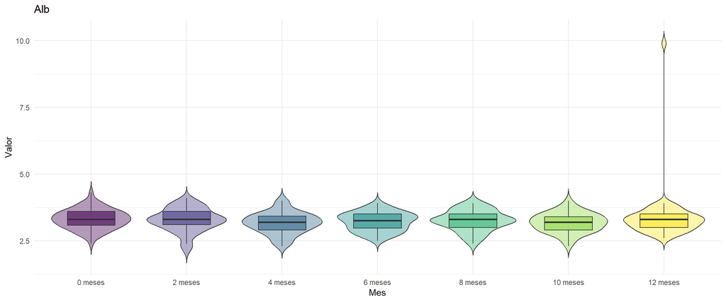

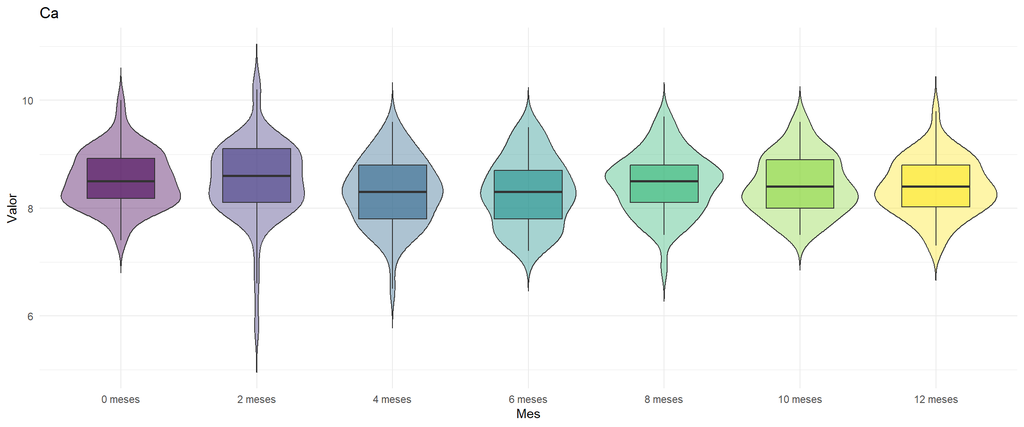

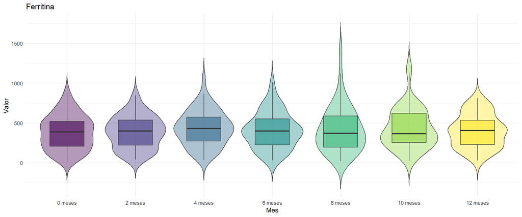

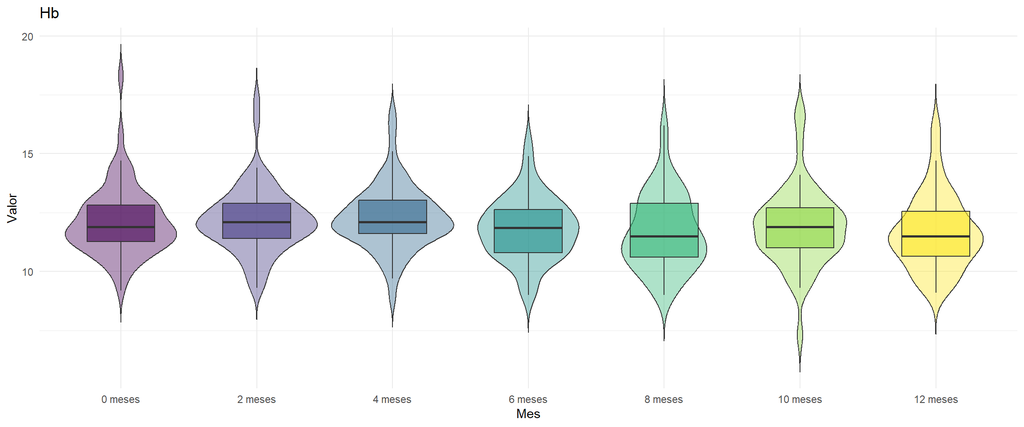

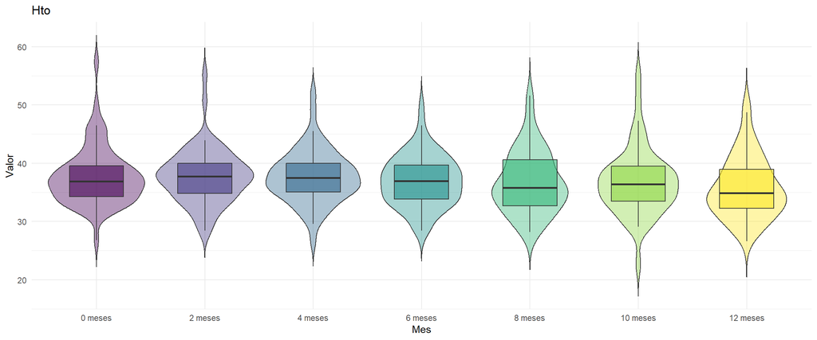

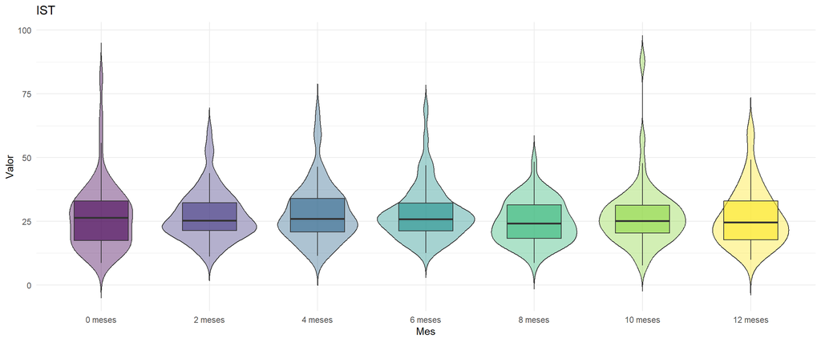

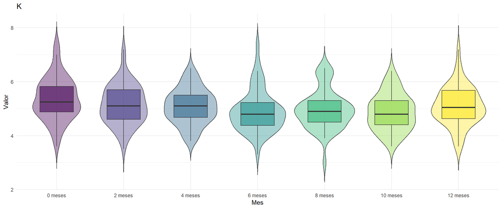

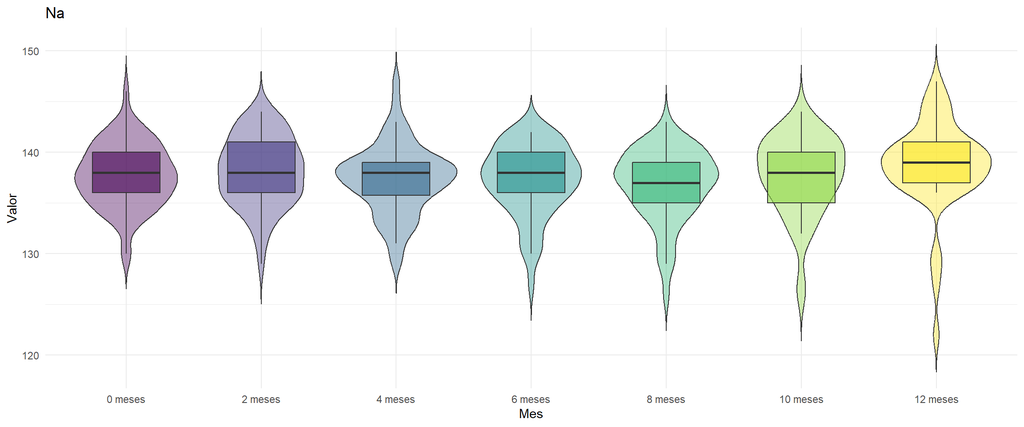

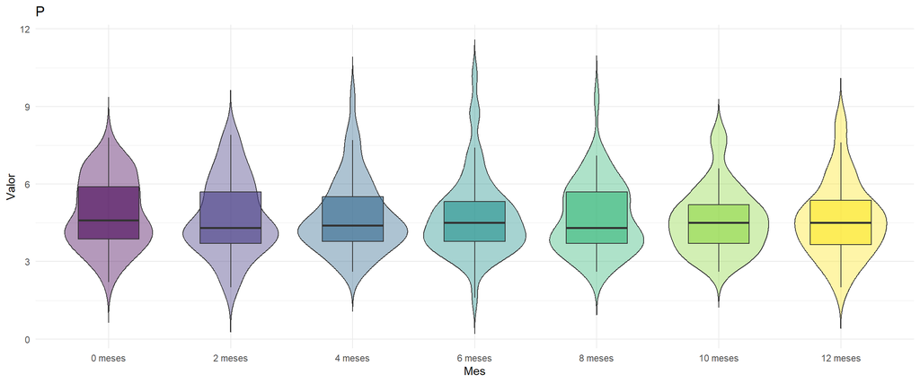

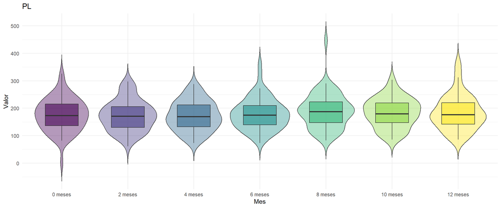

```
Estos 128 registros con meses vacío es porque en el mes 12 no existen las variables Dosis extra ni Dosis extra (dosis)
```

```
 0 meses  2 meses  4 meses  6 meses  8 meses 10 meses 12 meses     <NA>
     832      960      960      960      960      960      832      128
```

```r
data_long |> select(Mes,Variable) |> unique() |> filter(grepl("(dosis)", Variable, ignore.case = FALSE))
```

```
# A tibble: 5 × 2
  Mes      Variable
  <ord>    <chr>
1 2 meses  Dosis extra (dosis)
2 4 meses  Dosis extra (dosis)
3 6 meses  Dosis extra (dosis)
4 8 meses  Dosis extra (dosis)
5 10 meses Dosis extra (dosis)
```

```r
data_long |> filter(Variable=='Dosis extra (dosis)') |> select(Mes,value) |> group_by_all() |> count()
```

[output not shown]

```r
data_long |> select(Mes,Variable) |> unique() |> filter(grepl("Pauta", Variable, ignore.case = FALSE))
```

```
# A tibble: 0 × 2
# ℹ 2 variables: Mes <ord>, Variable <chr>
```

## Data structured

```r
# aux <- readRDS("data/data.RDA")
# data <- aux$data
# rm(aux)

# basales <- c(names(data)[1:20], names(data)[31:35], 'Es exitus', 'Momento exitus')
basales <- c(names(data)[1:20], 'Es exitus', 'Momento exitus')
```

```r
data1 <-
data |>
  rename_with(~ gsub("Control Basal", "Control 0 meses", .x), starts_with("Control Basal") & !any_of(basales)) |>
  # select(all_of(basales) | !contains("Control") | where(is.numeric)) |>
  select(all_of(basales) | where(is.numeric)) |>
  # mutate(across(starts_with("Control"), as.character)) |>  # convertir todo a character
  pivot_longer(
    cols = starts_with("Control") & !any_of(basales), # & !contains('Basal')
    names_to = c("Mes", "Variable"),
    names_pattern = "Control (\\d+ meses) (.+)"
  ) |>
  mutate(
    Mes = factor(
      Mes,
      levels = paste0(c(0, 2, 4, 6, 8, 10, 12), " meses"),  # orden personalizado
      ordered = TRUE
    )
  ) |>
  filter(!is.na(Mes)) |>
  arrange(id, as.numeric(sub(" meses", "", Mes)), Variable) |>
  pivot_wider(
    names_from = 'Variable'
  )
# data1 <- droplevels(data1)

data2 <-
  data |>
  rename_with(~ gsub("Control Basal", "Control 0 meses", .x), starts_with("Control Basal") & !any_of(basales)) |>
  select(all_of(basales) | !where(is.numeric)) |>
  # mutate(across(starts_with("Control"), as.character)) |>  # convertir todo a character
  pivot_longer(
    cols = starts_with("Control") & !any_of(basales), # & !contains('Basal')
    names_to = c("Mes", "Variable"),
    names_pattern = "Control (\\d+ meses) (.+)"
  ) |>
  mutate(
    Mes = factor(
      Mes,
      levels = paste0(c(0, 2, 4, 6, 8, 10, 12), " meses"),  # orden personalizado
      ordered = TRUE
    )
  ) |>
  filter(!is.na(Mes)) |>
  arrange(id, as.numeric(sub(" meses", "", Mes)), Variable) |>
  pivot_wider(
    names_from = 'Variable',
    names_repair = "unique"
  )
# data2 <- droplevels(data2)
```

```r
# df <- df |>
#   arrange(id) |>
#   group_by(id) |>
#   fill('Pauta (código)', .direction = "down") |>
#   ungroup()
# df <- df |>
#   arrange(id) |>
#   group_by(id) |>
#   fill('Pauta (código)', .direction = "up") |>
#   ungroup()

df <- df |> mutate(`Portador CT` = if_else(Mes == "0 meses" & is.na(`Portador CT`), `Control Basal Portador CT`, `Portador CT`),
                   `Portador FAV` = if_else(Mes == "0 meses" & is.na(`Portador FAV`), `Control Basal Portador FAV`, `Portador FAV`))
```

Variables excluidas: variables sin informar, variables con un único valor constante (no aportan información) y variables fechas no necesarias (nacimiento e inicio HD)

```r
cols_all_na <- colnames(df)[sapply(df, function(x) all(is.na(x)))]
cols_single_value <- colnames(df)[sapply(df, function(x) length(unique(x)) == 1)]
cols_single_value <- setdiff(cols_single_value, cols_all_na)
cols_fechas <- c('Fecha nacimiento', 'Fecha inicio HD')

list(
  all_NA = cols_all_na,
  single_value = cols_single_value,
  fechas = cols_fechas
)
```

```
$all_NA
character(0)

$single_value
[1] "Fecha inicio Estudio"         "Control Basal Portador ambos"

$fechas
[1] "Fecha nacimiento" "Fecha inicio HD"
```

```r
df <- df |> select(-c(cols_all_na, cols_single_value, cols_fechas))
```

Pacientes marcados como vivo por mes.

```r
df |> group_by(Mes) |> select(Vivo) |> table(useNA = 'always')
```

```
          Vivo
Mes         0  1 <NA>
  0 meses   0  0   64
  2 meses   1 63    0
  4 meses   1 60    3
  6 meses   1 56    7
  8 meses   2 53    9
  10 meses  2 51   11
  12 meses  0 50   14
  <NA>      0  0    0
```

En el mes cero (inicio del estudio) todos están vivos (aunque no tengamos un campo que lo especifique en la base de datos, pero parece más que obvio). El resto de valores perdidos puede ser por final de seguimiento o exitus: en ambos casos, vivo=0.  
- Si Vivo = ’’ y lag(causa_exitus) = ‘0 -> fin de seguimiento  
- Si Vivo =’’ y lag(causa_exitus) != ’0 -> exitus

```r
df |> group_by(Mes) |> select(Vivo) |> table(useNA = 'always')
```

```
          Vivo
Mes         0  1 <NA>
  0 meses   0 64    0
  2 meses   0 64    0
  4 meses   3 61    0
  6 meses   7 57    0
  8 meses   9 55    0
  10 meses 11 53    0
  12 meses 14 50    0
  <NA>      0  0    0
```

```r
df |>
    group_by(id) |>
    summarise(n_Pautas_by_id = n_distinct('Pauta'), .groups = "drop") |> select(n_Pautas_by_id) |> table()
```

```
n_Pautas_by_id
 1
64
```

### Ejemplos

```r
df |>
    group_by(id) |>
    summarise(n_Dosis_FEE_semanal_Darbepoetina_by_id = n_distinct(`Dosis FEE semanal Darbepoetina`), .groups = "drop") |> select(n_Dosis_FEE_semanal_Darbepoetina_by_id) |> table()
```

```
n_Dosis_FEE_semanal_Darbepoetina_by_id
 1  2  3  4  5
41  6 10  5  2
```

```r
df |>
    group_by(id) |>
    summarise(n_Dosis_FEE_semanal_Beta_eritropoyetina = n_distinct(`Dosis FEE semanal Beta eritropoyetina`), .groups = "drop") |> select(n_Dosis_FEE_semanal_Beta_eritropoyetina) |> table()
```

```
n_Dosis_FEE_semanal_Beta_eritropoyetina
 1  2  3  4  5  6  7
10 18 14 15  4  2  1
```

Ejemplo id 1. (mirar desde RStudio)

```r
# df[df$id==1 & df$Mes !='0 meses',] |> View(title = 'id 1')
print(df[df$id==1,])
## # A tibble: 7 × 48
##      id HD    Aleatorización Sexo   Edad DM    Sintrom `Etiologia - ERC`
##   <dbl> <fct> <fct>          <fct> <dbl> <fct> <fct>   <fct>
## 1     1 0     Ferinject      0        54 1     1       Nefropatía diabética
## 2     1 0     Ferinject      0        54 1     1       Nefropatía diabética
## 3     1 0     Ferinject      0        54 1     1       Nefropatía diabética
## 4     1 0     Ferinject      0        54 1     1       Nefropatía diabética
## 5     1 0     Ferinject      0        54 1     1       Nefropatía diabética
## 6     1 0     Ferinject      0        54 1     1       Nefropatía diabética
## 7     1 0     Ferinject      0        54 1     1       Nefropatía diabética
## # ℹ 40 more variables: `Etiologia - ERC (código)` <fct>,
## #   `Tiempo hasta inicio estudio (meses)` <dbl>,
## #   `Control Basal Portador CT` <fct>, `Control Basal Portador FAV` <fct>,
## #   `Control Basal Portador PTFE` <fct>, `FAV RC` <fct>, `FAV HC` <fct>,
## #   `FAV HB` <fct>, `Es exitus` <int>, `Momento exitus` <fct>, Mes <ord>,
## #   Alb <dbl>, Ca <dbl>, `Dosis FEE semanal Beta eritropoyetina` <dbl>,
## #   `Dosis FEE semanal Darbepoetina` <dbl>, `Dosis Fe semanal` <dbl>, …
```

Ejemplo id 3. (mirar desde RStudio)

```r
# df[df$id==3 & df$Mes !='0 meses',] |> View(title = 'id 3')
print(df[df$id==3,])
## # A tibble: 7 × 48
##      id HD    Aleatorización Sexo   Edad DM    Sintrom `Etiologia - ERC`
##   <dbl> <fct> <fct>          <fct> <dbl> <fct> <fct>   <fct>
## 1     3 0     Ferinject      1        80 0     0       Nefroangioesclerosis
## 2     3 0     Ferinject      1        80 0     0       Nefroangioesclerosis
## 3     3 0     Ferinject      1        80 0     0       Nefroangioesclerosis
## 4     3 0     Ferinject      1        80 0     0       Nefroangioesclerosis
## 5     3 0     Ferinject      1        80 0     0       Nefroangioesclerosis
## 6     3 0     Ferinject      1        80 0     0       Nefroangioesclerosis
## 7     3 0     Ferinject      1        80 0     0       Nefroangioesclerosis
## # ℹ 40 more variables: `Etiologia - ERC (código)` <fct>,
## #   `Tiempo hasta inicio estudio (meses)` <dbl>,
## #   `Control Basal Portador CT` <fct>, `Control Basal Portador FAV` <fct>,
## #   `Control Basal Portador PTFE` <fct>, `FAV RC` <fct>, `FAV HC` <fct>,
## #   `FAV HB` <fct>, `Es exitus` <int>, `Momento exitus` <fct>, Mes <ord>,
## #   Alb <dbl>, Ca <dbl>, `Dosis FEE semanal Beta eritropoyetina` <dbl>,
## #   `Dosis FEE semanal Darbepoetina` <dbl>, `Dosis Fe semanal` <dbl>, …
```

Valores medio de FEE por mes de las dos ramas de aleatorización (Venofer y Ferinject).

```r
aux <-
df|>
  group_by(Aleatorización,Mes) |>
  summarise(
    n = n(),
    Vivo = sum(Vivo=='1'),
    media_FEE_beta = mean(`Dosis FEE semanal Beta eritropoyetina`, na.rm = TRUE),
    media_FEE_darbe = mean(`Dosis FEE semanal Darbepoetina`, na.rm = TRUE),
    .groups = "drop"
  )

for (i in unique(aux$Aleatorización)){
  aux |> filter(Aleatorización==i) |> pivot_wider(
    names_from = 'Aleatorización',
    values_from = c(n, media_FEE_beta, media_FEE_darbe)
    # names_sep = "_"
    ) |>
  print(n = Inf, width = Inf)
}
```

```
# A tibble: 7 × 5
  Mes       Vivo n_Venofer media_FEE_beta_Venofer media_FEE_darbe_Venofer
  <ord>    <int>     <int>                  <dbl>                   <dbl>
1 0 meses     30        30                  6907.                    43.3
2 2 meses     30        30                  7783.                    21.7
3 4 meses     30        30                  5280                     18
4 6 meses     27        30                  4167.                    30
5 8 meses     26        30                  4304.                    30
6 10 meses    25        30                  4773.                    30
7 12 meses    23        30                  4905.                    30
# A tibble: 7 × 5
  Mes       Vivo n_Ferinject media_FEE_beta_Ferinject media_FEE_darbe_Ferinject
  <ord>    <int>       <int>                    <dbl>                     <dbl>
1 0 meses     34          34                    9455.                      48.7
2 2 meses     34          34                    5300                       35
3 4 meses     31          34                    3895.                      19.1
4 6 meses     30          34                    3595.                      32.2
5 8 meses     29          34                    4426.                      40
6 10 meses    28          34                    7556.                      35.6
7 12 meses    27          34                   10104                       29.3
```

## Save

```r
saveRDS(list(data_estructured = df), "data/df_analisis_y_modelos.RDA")
```